# Lab 4

Amanda Murphy

10/5/2021

```r
rolls <- sample(1:6,10000, replace=TRUE)
table(rolls)
```

```
## rolls
##    1    2    3    4    5    6
## 1633 1709 1668 1634 1670 1686
```

```r
one <- sample(1:6,10000,replace=TRUE)
two <- sample(1:6,10000, replace=TRUE)
combined <- one+two
table(combined)/10000
```

```
## combined
##      2      3      4      5      6      7      8      9     10     11     12
## 0.0262 0.0539 0.0822 0.1156 0.1378 0.1628 0.1424 0.1097 0.0874 0.0534 0.0286
```

```r
first <- rep(1:6, each = 6)
second <- rep(1:6,6)
sum_rolls <- first+second
table(sum_rolls)/length(sum_rolls)
```

```
## sum_rolls
##          2          3          4          5          6          7          8
## 0.02777778 0.05555556 0.08333333 0.11111111 0.13888889 0.16666667 0.13888889
##          9         10         11         12
## 0.11111111 0.08333333 0.05555556 0.02777778
```

```r
sim_result <- table(combined)/10000
true_probs <- table(sum_rolls)/length(sum_rolls)

true_probs-sim_result
```

```
## sum_rolls
##             2             3             4             5             6
##  0.0015777778  0.0016555556  0.0011333333 -0.0044888889  0.0010888889
##             7             8             9            10            11
##  0.0038666667 -0.0035111111  0.0014111111 -0.0040666667  0.0021555556
##            12
## -0.0008222222
```

```r
sample(c("A","B"), 20, replace = TRUE, prob = c(.8, .2))
```

```
##  [1] "A" "A" "A" "A" "A" "A" "A" "B" "A" "A" "A" "A" "A" "A" "B" "B" "A" "A" "A"
## [20] "A"
```

```r
letters
```

```
##  [1] "a" "b" "c" "d" "e" "f" "g" "h" "i" "j" "k" "l" "m" "n" "o" "p" "q" "r" "s"
## [20] "t" "u" "v" "w" "x" "y" "z"
```

```r
LETTERS
```

```
##  [1] "A" "B" "C" "D" "E" "F" "G" "H" "I" "J" "K" "L" "M" "N" "O" "P" "Q" "R" "S"
## [20] "T" "U" "V" "W" "X" "Y" "Z"
```

```r
sample(letters,50,replace=TRUE)
```

```
##  [1] "p" "j" "e" "p" "a" "f" "z" "q" "s" "v" "u" "r" "f" "o" "m" "y" "u" "v" "u"
## [20] "y" "j" "r" "z" "d" "z" "s" "b" "l" "s" "h" "u" "v" "o" "r" "c" "g" "l" "u"
## [39] "g" "y" "e" "f" "q" "s" "y" "s" "n" "y" "f" "q"
```

```r
my_letters <- sample(letters,50*5,replace=TRUE)
my_strings <- matrix(my_letters, ncol = 5)

paste(my_strings[1,], collapse="")
```

```
## [1] "fpvlz"
```

```r
random_strings <-c()
for(i in 1:dim(my_strings)[1]){
  random_strings[i] <- paste(my_strings[i,], collapse="")
}

random_strings
```

```
##  [1] "fpvlz" "ftgwi" "isjla" "vglbu" "jzlen" "ptwjw" "oilbx" "euciv" "yeerj"
## [10] "jnzut" "gxslr" "vykuz" "fidyj" "ekvnz" "mvzvt" "occdr" "zogte" "barft"
## [19] "nheao" "ehmxm" "waajy" "uyjby" "zmydj" "qnggm" "pvvrd" "vqkek" "cyxqx"
## [28] "gfmwq" "ucdso" "bnqfm" "tkojz" "tevyl" "jorfc" "cptdl" "xxjaa" "ndazy"
## [37] "rcugf" "fdvrc" "bxyrh" "unlae" "adfvg" "sqvqj" "eneea" "fuspm" "bbwfj"
## [46] "yzxzd" "kzfky" "nooxu" "fbwkm" "kehea"
```

```r
sim_results <- replicate(10000,
                         sample( c(1,0), 10, replace=TRUE)
                         )
number_of_heads <- colSums(sim_results)
table(number_of_heads)/10000
```

```
## number_of_heads
##      0      1      2      3      4      5      6      7      8      9     10
## 0.0010 0.0094 0.0442 0.1175 0.2096 0.2436 0.2039 0.1174 0.0424 0.0102 0.0008
```

```r
number_of_heads <- rbinom(10000,10,prob=.5)
table(number_of_heads)/10000
```

```
## number_of_heads
##      0      1      2      3      4      5      6      7      8      9     10
## 0.0009 0.0088 0.0427 0.1177 0.2070 0.2501 0.2060 0.1145 0.0428 0.0084 0.0011
```

```r
flips <- sample(c("H","T"), 10000, replace=TRUE)

sequence <- c()
for(i in 2:length(flips)){
  first_element <- flips[i-1]
  second_element <- flips[i]
  sequence[i-1] <- paste0(first_element,second_element)
}




table(sequence)/sum(table(sequence))
```

```
## sequence
##        HH        HT        TH        TT
## 0.2523252 0.2476248 0.2475248 0.2525253
```

```r
flips <- sample(c("H","T"), 10000, replace=TRUE)

sequence <- c()
for(i in 3:length(flips)){
  first_element <- flips[i-2]
  second_element <- flips[i-1]
  third_element <- flips[i]
  sequence[i-1] <- paste0(first_element,
                          second_element,
                          third_element)
}

table(sequence)/sum(table(sequence))
```

```
## sequence
##       HHH       HHT       HTH       HTT       THH       THT       TTH       TTT
## 0.1237247 0.1248250 0.1203241 0.1276255 0.1247249 0.1231246 0.1275255 0.1281256
```

Generalization Problems Lab 4

1. Estimate the letter occurrence probabilities of all 26 letters in English by measuring a paragraph of English text from wikipedia. (hint use strsplit() to split a paragraph into individual letters) (1 point).

```r
wikipedia <- "Tecumseh (c. 1768 – October 5, 1813) was a Shawnee chief and warrior who promoted resistance to the expansion of the United States onto Native American lands. During Tecumseh's childhood, the Shawnee lost territory to the American colonies in a series of border conflicts. A persuasive orator, Tecumseh traveled widely, forming a Native American confederacy and promoting tribal unity. He proclaimed that Native Americans owned their lands in common, and urged tribes not to cede more territory unless all agreed. In the War of 1812, Tecumseh joined his cause with the British, recruiting warriors and helping to capture Detroit in 1812. In 1813, he retreated with the British into Upper Canada, where American forces engaged them at the Battle of the Thames, in which Tecumseh was killed. His death led to the collapse of his confederacy, but he became an iconic folk hero in American, Indigenous, and Canadian history."

wikipedia_letters <- unlist(strsplit(wikipedia, split = ""))
lower_case <- tolower(wikipedia_letters)
letter_counts <- table(lower_case)
letter_counts <- as.data.frame(letter_counts)

library(dplyr)
final <-letter_counts %>%
  filter(lower_case %in% letters == TRUE)

total_letters <- sum(final$Freq)

final <- final %>%
  mutate(probabilities = Freq/total_letters)

knitr::kable(final)
```

| lower_case | Freq | probabilities |
| --- | --- | --- |
| a | 63 | 0.0867769 |
| b | 9 | 0.0123967 |
| c | 37 | 0.0509642 |
| d | 32 | 0.0440771 |
| e | 96 | 0.1322314 |
| f | 12 | 0.0165289 |
| g | 10 | 0.0137741 |
| h | 42 | 0.0578512 |
| i | 61 | 0.0840220 |
| j | 1 | 0.0013774 |
| k | 2 | 0.0027548 |
| l | 21 | 0.0289256 |
| m | 21 | 0.0289256 |
| n | 54 | 0.0743802 |
| o | 52 | 0.0716253 |
| p | 10 | 0.0137741 |
| r | 54 | 0.0743802 |
| s | 40 | 0.0550964 |
| t | 65 | 0.0895317 |
| u | 17 | 0.0234160 |
| v | 5 | 0.0068871 |
| w | 14 | 0.0192837 |
| x | 1 | 0.0013774 |
| y | 7 | 0.0096419 |

2. Generate “random” strings of letters that are sampled from a distribution where letter occurrence probability is the same as natural English. Use the probabilities for each letter from this wikipedia article, or use your own estimates from the previous question (2 points).

```r
my_letters <- sample(final$lower_case,50*5,replace=TRUE, prob = final$probabilities)

# turn the vector into a matrix with 5 columns
my_strings <- matrix(my_letters, ncol=5)

# each row is a word, need to collapse the column to create a string
paste(my_strings[1,], collapse="")
```

```
## [1] "igtct"
```

[output not shown]

```r
# loop to collapse all of the rows into words
random_strings <-c()
for(i in 1:dim(my_strings)[1]){
  random_strings[i] <- paste(my_strings[i,], collapse="")
}

random_strings
```

```
##  [1] "igtct" "hmctf" "elars" "womtd" "snomh" "rhrsp" "riirt" "ysudt" "eoeea"
## [10] "repet" "deost" "talhd" "ioori" "aatrr" "ieout" "nenea" "wperc" "ruird"
## [19] "rcous" "noari" "srciv" "eaopw" "ripmh" "frcoh" "iatcu" "ctien" "cetsn"
## [28] "ereed" "wscvm" "oiarn" "nabra" "hlece" "feidd" "ttech" "lhess" "laysr"
## [37] "htdei" "tsdme" "tnloe" "laait" "evrwi" "eeetb" "yatve" "oatth" "nrand"
## [46] "epoht" "myleh" "hlmab" "mgwhn" "eenwa"
```

3.Generate a random walk of 10,000 steps. In a random walk, you are simulating the process of randomly taking a step up or down, as if you are on an infinite staircase. At each step you flip a coin. If you get heads you go up one step, if you get tails you go down one step. Start on step 0, then simulate a random walk for 10,000 steps. Your vector should preserve the step number for each step. For example, if the the first three steps were all heads, then the vector would begin with 0,1,2,3, which indicates a single step up each time. Plot the first 1,000 steps. (1 point)

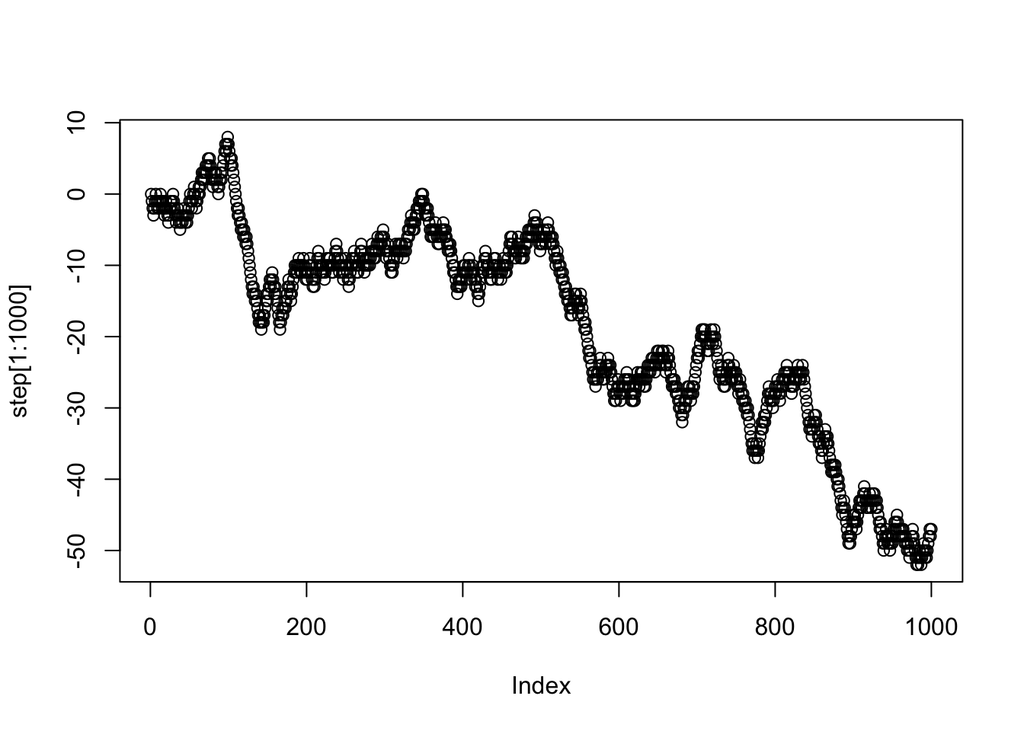

```r
step <- c(0)
for(i in 1:10000){
  coin_flip <- sample(c(1,-1),1)
  step[i+1] <- step[i] + coin_flip
}

plot(step[1:1000])
```

4.What was the most positive and most negative step reached out of 10,000? (1 point)

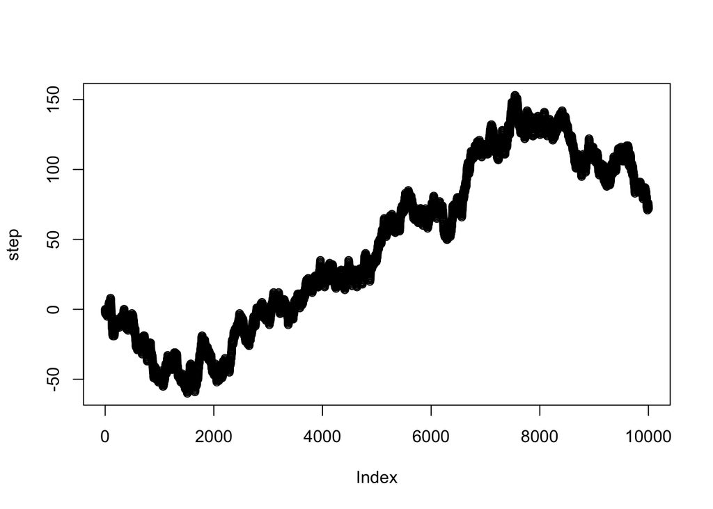

```r
plot(step)
```

```r
max(step)
```

```
## [1] 153
```

```r
min(step)
```

```
## [1] -60
```

5.What was the longest run of steps where all steps were positive numbers. For example, in the sequence: 1,2,3,2,1,0,-1,-2,-1,-2,-1,0,1,2,3; the answer is 5 because the first five values were all positive, and this was the longest sequence of positive values. (1 point).

```r
logical_step <- sign(step)

sequence <- c()
counter <- 0
for(i in 1:length(logical_step)){
  if(logical_step[i] == 0){
    sequence <- c(sequence,counter)
    counter <- 0
  } else {
    counter <- counter+logical_step[i]
  }
}

max(sequence)
```

```
## [1] 143
```

```r
min(sequence)
```

```
## [1] -2439
```